# **Ford Go-bike** Dataset Exploration Project

## Preliminary Wrangling

> This data set includes information about individual rides made in a bike-sharing system covering the greater San Francisco Bay area during Febreuary 2019.

```python
# import all packages and set plots to be embedded inline
import numpy as np
import pandas as pd
import matplotlib.pyplot as plt
import seaborn as sb
from matplotlib import rcParams

%matplotlib inline
```

# **Data set Assessment**:

> In this section I will Load the dataset and describe its properties through programatic assessment.

```python
# load in the dataset into a pandas dataframe
df = pd.read_csv ('201902-fordgobike-tripdata.csv')

# test
df.head()
```

|  | duration_sec | start_time | end_time | start_station_id | start_station_name | start_station_latitude | start_station_longitude | end_station_id | end_station_name | end_station_latitude | end_station_longitude | bike_id | user_type | member_birth_year | member_gender | bike_share_for_all_trip |
| --- | --- | --- | --- | --- | --- | --- | --- | --- | --- | --- | --- | --- | --- | --- | --- | --- |
| 0 | 52185 | 2019-02-28 17:32:10.1450 | 2019-03-01 08:01:55.9750 | 21.0 | Montgomery St BART Station (Market St at 2nd St) | 37.789625 | -122.400811 | 13.0 | Commercial St at Montgomery St | 37.794231 | -122.402923 | 4902 | Customer | 1984.0 | Male | No |
| 1 | 42521 | 2019-02-28 18:53:21.7890 | 2019-03-01 06:42:03.0560 | 23.0 | The Embarcadero at Steuart St | 37.791464 | -122.391034 | 81.0 | Berry St at 4th St | 37.775880 | -122.393170 | 2535 | Customer | NaN | NaN | No |
| 2 | 61854 | 2019-02-28 12:13:13.2180 | 2019-03-01 05:24:08.1460 | 86.0 | Market St at Dolores St | 37.769305 | -122.426826 | 3.0 | Powell St BART Station (Market St at 4th St) | 37.786375 | -122.404904 | 5905 | Customer | 1972.0 | Male | No |
| 3 | 36490 | 2019-02-28 17:54:26.0100 | 2019-03-01 04:02:36.8420 | 375.0 | Grove St at Masonic Ave | 37.774836 | -122.446546 | 70.0 | Central Ave at Fell St | 37.773311 | -122.444293 | 6638 | Subscriber | 1989.0 | Other | No |
| 4 | 1585 | 2019-02-28 23:54:18.5490 | 2019-03-01 00:20:44.0740 | 7.0 | Frank H Ogawa Plaza | 37.804562 | -122.271738 | 222.0 | 10th Ave at E 15th St | 37.792714 | -122.248780 | 4898 | Subscriber | 1974.0 | Male | Yes |

```python
# high-level overview of data shape and composition
print(df.shape)
print(df.dtypes)
print(df.info())
```

```
(183412, 16)
duration_sec                 int64
start_time                  object
end_time                    object
start_station_id           float64
start_station_name          object
start_station_latitude     float64
start_station_longitude    float64
end_station_id             float64
end_station_name            object
end_station_latitude       float64
end_station_longitude      float64
bike_id                      int64
user_type                   object
member_birth_year          float64
member_gender               object
bike_share_for_all_trip     object
dtype: object
<class 'pandas.core.frame.DataFrame'>
RangeIndex: 183412 entries, 0 to 183411
Data columns (total 16 columns):
 #   Column                   Non-Null Count   Dtype
---  ------                   --------------   -----
 0   duration_sec             183412 non-null  int64
 1   start_time               183412 non-null  object
 2   end_time                 183412 non-null  object
 3   start_station_id         183215 non-null  float64
 4   start_station_name       183215 non-null  object
 5   start_station_latitude   183412 non-null  float64
 6   start_station_longitude  183412 non-null  float64
 7   end_station_id           183215 non-null  float64
 8   end_station_name         183215 non-null  object
 9   end_station_latitude     183412 non-null  float64
 10  end_station_longitude    183412 non-null  float64
 11  bike_id                  183412 non-null  int64
 12  user_type                183412 non-null  object
 13  member_birth_year        175147 non-null  float64
 14  member_gender            175147 non-null  object
 15  bike_share_for_all_trip  183412 non-null  object
dtypes: float64(7), int64(2), object(7)
memory usage: 22.4+ MB
None
```

```python
# descriptive statistics for numeric variables
df.describe()
```

|  | duration_sec | start_station_id | start_station_latitude | start_station_longitude | end_station_id | end_station_latitude | end_station_longitude | bike_id | member_birth_year |
| --- | --- | --- | --- | --- | --- | --- | --- | --- | --- |
| count | 183412.000000 | 183215.000000 | 183412.000000 | 183412.000000 | 183215.000000 | 183412.000000 | 183412.000000 | 183412.000000 | 175147.000000 |
| mean | 726.078435 | 138.590427 | 37.771223 | -122.352664 | 136.249123 | 37.771427 | -122.352250 | 4472.906375 | 1984.806437 |
| std | 1794.389780 | 111.778864 | 0.099581 | 0.117097 | 111.515131 | 0.099490 | 0.116673 | 1664.383394 | 10.116689 |
| min | 61.000000 | 3.000000 | 37.317298 | -122.453704 | 3.000000 | 37.317298 | -122.453704 | 11.000000 | 1878.000000 |
| 25% | 325.000000 | 47.000000 | 37.770083 | -122.412408 | 44.000000 | 37.770407 | -122.411726 | 3777.000000 | 1980.000000 |
| 50% | 514.000000 | 104.000000 | 37.780760 | -122.398285 | 100.000000 | 37.781010 | -122.398279 | 4958.000000 | 1987.000000 |
| 75% | 796.000000 | 239.000000 | 37.797280 | -122.286533 | 235.000000 | 37.797320 | -122.288045 | 5502.000000 | 1992.000000 |
| max | 85444.000000 | 398.000000 | 37.880222 | -121.874119 | 398.000000 | 37.880222 | -121.874119 | 6645.000000 | 2001.000000 |

```python
# Displaying the number of duplicates
sum(df.duplicated())
```

```
0
```

```python
# Displaying the unique values of each column of each dataframe
df.nunique()
```

```
duration_sec                 4752
start_time                 183401
end_time                   183397
start_station_id              329
start_station_name            329
start_station_latitude        334
start_station_longitude       335
end_station_id                329
end_station_name              329
end_station_latitude          335
end_station_longitude         335
bike_id                      4646
user_type                       2
member_birth_year              75
member_gender                   3
bike_share_for_all_trip         2
dtype: int64
```

- Inspecting the value counts of the dataframe columns:

```python
df.user_type.value_counts()
```

```
Subscriber    163544
Customer       19868
Name: user_type, dtype: int64
```

```python
df.start_station_name.value_counts()
```

```
Market St at 10th St                                         3904
San Francisco Caltrain Station 2  (Townsend St at 4th St)    3544
Berry St at 4th St                                           3052
Montgomery St BART Station (Market St at 2nd St)             2895
Powell St BART Station (Market St at 4th St)                 2760
                                                             ...
Willow St at Vine St                                            9
Parker Ave at McAllister St                                     7
Palm St at Willow St                                            4
21st Ave at International Blvd                                  4
16th St Depot                                                   2
Name: start_station_name, Length: 329, dtype: int64
```

```python
df.end_station_name.value_counts()
```

```
San Francisco Caltrain Station 2  (Townsend St at 4th St)    4857
Market St at 10th St                                         3973
Montgomery St BART Station (Market St at 2nd St)             3647
San Francisco Ferry Building (Harry Bridges Plaza)           3368
Powell St BART Station (Market St at 4th St)                 2997
                                                             ...
Parker Ave at McAllister St                                     9
Palm St at Willow St                                            7
16th St Depot                                                   6
21st Ave at International Blvd                                  6
Willow St at Vine St                                            5
Name: end_station_name, Length: 329, dtype: int64
```

```python
df.member_birth_year.value_counts()
```

```
1988.0    10236
1993.0     9325
1989.0     8972
1990.0     8658
1991.0     8498
          ...
1930.0        1
1910.0        1
1927.0        1
1928.0        1
1878.0        1
Name: member_birth_year, Length: 75, dtype: int64
```

```python
df.member_gender.value_counts()
```

```
Male      130651
Female     40844
Other       3652
Name: member_gender, dtype: int64
```

```python
df.bike_share_for_all_trip.value_counts()
```

```
No     166053
Yes     17359
Name: bike_share_for_all_trip, dtype: int64
```

```python
df.duration_sec.value_counts()
```

```
272      311
324      292
323      291
306      291
305      290
        ...
5803       1
11870      1
5931       1
15964      1
5058       1
Name: duration_sec, Length: 4752, dtype: int64
```

- Viewing the missing value count for each column:

```python
# view missing value count for each column:
df.isnull().sum()
```

```
duration_sec                  0
start_time                    0
end_time                      0
start_station_id            197
start_station_name          197
start_station_latitude        0
start_station_longitude       0
end_station_id              197
end_station_name            197
end_station_latitude          0
end_station_longitude         0
bike_id                       0
user_type                     0
member_birth_year          8265
member_gender              8265
bike_share_for_all_trip       0
dtype: int64
```

- Sorting the values of some columns:

```python
# Sorting the values of `member_birth_year` column
df.member_birth_year.sort_values()
```

```
27370     1878.0
72711     1900.0
41319     1900.0
173711    1900.0
94616     1900.0
           ...
183354       NaN
183356       NaN
183363       NaN
183371       NaN
183402       NaN
Name: member_birth_year, Length: 183412, dtype: float64
```

```python
# Sorting the values of `start_time` column
df.start_time.sort_values()
```

```
183411    2019-02-01 00:00:20.6360
183406    2019-02-01 00:04:40.6160
183407    2019-02-01 00:04:49.7240
183410    2019-02-01 00:05:34.3600
183408    2019-02-01 00:05:34.7440
                    ...
6         2019-02-28 23:55:35.1040
14        2019-02-28 23:56:26.8480
11        2019-02-28 23:56:55.5400
10        2019-02-28 23:57:57.2110
15        2019-02-28 23:59:18.5480
Name: start_time, Length: 183412, dtype: object
```

## Findings

> In this section I will state the properities of the dataset after the programatic assessment, and if any cleaning is needed before further analysis.

### The structure of **Ford Gobike-tripdata** dataset?

- The data set consists of 183412 entries.
- There are 16 columns of variable data types
- Columns' Data types are:

  > float64(7), int64(2), object(7)
- There are 197 missing data in `start_station_id`, `start_station_name`, `end_station_id`, and `end_station_name` columns.
- There are 8265 missing data in `member_birth_year` and `member_gender` columns.
- There are no duplicate data.
- There are 75 different ages of the users involved in the study, 329 start and end stations, 2 user types, 3 gender entries, 4752 trip durations, and 2 conditions of bike share.

### Cleaning needed:

1. Making a copy for the dataframe before cleaning, named 'bike'.
2. Drop the un-necessary rows:
   - Row with NaN values in `member_gender` and `start_station_id` columns -Rows with odd values:
     - 'Other' in `member_gender` column
     - Odd values < 1920 in `member_birth_year` column
3. Dropping the unnecessary columns:

   > `start_station_id`, `start_station_latitude`, `start_station_longitude`, `end_station_id`, `end_station_latitude`, `end_station_longitude`, and `bike_id`.
4. Reset the index of the bike dataframe.
5. Convert the type of some columns:
   - `start_time` and `end_time` columns from object to date-time
   - `member_birth_year` column from float to integer
6. Split the datetime columns into date columns and time columns:
   - `start_time` column to `start_time` and `start_date` columns
   - `end_time` column to `end_time` and `end_date` columns

### The structure of the cleaned `bike` dataset:

- Consistes of 171234 entries and 11 columns.
- No missing values.
- Columns data types are:

  > int64(2), object(9)

### What is/are the main feature(s) of interest in your dataset?

- I'm most interested in figuring out what features are best for predicting the rate and length of bike rides in the tested bike-sharing system.
- When are most trips taken in terms of time of day, day of the week?
- How long does the average trip take?
- Does the above depend on if a user is a subscriber or customer, male or female, bike share for all trip or not?

### What features in the dataset do you think will help support your investigation into your feature(s) of interest?

- I think that age of the user may play a significant role in the rate of riding biking.
- Also gender and subscribtion status may affect the choice of taking a bike ride.
- Additionally, the length or duration of the trip may constitute a factor affecting choice to ride.

# **Cleaning**

> In this section I will adjust some quality and tidiness issues in the data set, to be easeir for analysis
1. Make a new copy of the data frame before cleaning, to not affect the original file

```python
# Make a copy for the dataframe before cleaning:
bike = df.copy()
```

1. Drop the un-necessary rows:
   - Row with NaN values in `member_gender` and `start_station_id` columns
   - Rows with odd values:
     - 'Other' in `member_gender` column
     - Odd values < 1920 in `member_birth_year` column

```python
# drop rows whose value is NaN from `member_gender` and `start_station_id` columns
bike = bike[bike['member_gender'].notna()]
bike = bike[bike['start_station_id'].notna()]

# testing
bike.isnull().sum()
```

```
duration_sec               0
start_time                 0
end_time                   0
start_station_id           0
start_station_name         0
start_station_latitude     0
start_station_longitude    0
end_station_id             0
end_station_name           0
end_station_latitude       0
end_station_longitude      0
bike_id                    0
user_type                  0
member_birth_year          0
member_gender              0
bike_share_for_all_trip    0
dtype: int64
```

```python
# Drop all row in `member_gender` column that equal 'Other'
bike = bike[bike.member_gender != 'Other']

# testing
bike.member_gender.value_counts()
```

```
Male      130500
Female     40805
Name: member_gender, dtype: int64
```

```python
# Drop all row in `member_birth_year` column that are before 1920
bike = bike[bike.member_birth_year >= 1920]

# testing
bike.member_birth_year.value_counts()
```

```
1988.0    10015
1993.0     9145
1989.0     8805
1990.0     8495
1991.0     8339
          ...
1938.0        3
1920.0        3
1944.0        2
1934.0        2
1927.0        1
Name: member_birth_year, Length: 68, dtype: int64
```

1. Drop the un-necessary columns: `'start_station_id', 'start_station_latitude', 'start_station_longitude',

   ```
                'end_station_id', 'end_station_latitude', 'end_station_longitude', 'bike_id'`
   ```

```python
# drop unnecessary columns
bike.drop(['start_station_id', 'start_station_latitude', 'start_station_longitude',
                    'end_station_id', 'end_station_latitude', 'end_station_longitude', 'bike_id'],axis=1, inplace=True)

# testing
bike.info()
```

```
<class 'pandas.core.frame.DataFrame'>
Int64Index: 171234 entries, 0 to 183411
Data columns (total 9 columns):
 #   Column                   Non-Null Count   Dtype
---  ------                   --------------   -----
 0   duration_sec             171234 non-null  int64
 1   start_time               171234 non-null  object
 2   end_time                 171234 non-null  object
 3   start_station_name       171234 non-null  object
 4   end_station_name         171234 non-null  object
 5   user_type                171234 non-null  object
 6   member_birth_year        171234 non-null  float64
 7   member_gender            171234 non-null  object
 8   bike_share_for_all_trip  171234 non-null  object
dtypes: float64(1), int64(1), object(7)
memory usage: 13.1+ MB
```

1. Reset the index of the dataframe

```python
# reset the index of the bike dataframe
bike.reset_index(drop=True, inplace=True)

# testing
bike.info()
```

```
<class 'pandas.core.frame.DataFrame'>
RangeIndex: 171234 entries, 0 to 171233
Data columns (total 9 columns):
 #   Column                   Non-Null Count   Dtype
---  ------                   --------------   -----
 0   duration_sec             171234 non-null  int64
 1   start_time               171234 non-null  object
 2   end_time                 171234 non-null  object
 3   start_station_name       171234 non-null  object
 4   end_station_name         171234 non-null  object
 5   user_type                171234 non-null  object
 6   member_birth_year        171234 non-null  float64
 7   member_gender            171234 non-null  object
 8   bike_share_for_all_trip  171234 non-null  object
dtypes: float64(1), int64(1), object(7)
memory usage: 11.8+ MB
```

1. Convert the type of some columns:
   - `start_time` and `end_time` columns from object to date-time
   - `member_birth_year` column from float to integer

```python
# convert `start_time` and `end_time` columns from object to date-time
bike['start_time'] =  pd.to_datetime(bike['start_time'])
bike['end_time'] =  pd.to_datetime(bike['end_time'])

# convert `member_birth_year` column from float to integer
bike['member_birth_year']= bike['member_birth_year'].astype(int)

# testing
bike.info()
```

```
<class 'pandas.core.frame.DataFrame'>
RangeIndex: 171234 entries, 0 to 171233
Data columns (total 9 columns):
 #   Column                   Non-Null Count   Dtype
---  ------                   --------------   -----
 0   duration_sec             171234 non-null  int64
 1   start_time               171234 non-null  datetime64[ns]
 2   end_time                 171234 non-null  datetime64[ns]
 3   start_station_name       171234 non-null  object
 4   end_station_name         171234 non-null  object
 5   user_type                171234 non-null  object
 6   member_birth_year        171234 non-null  int64
 7   member_gender            171234 non-null  object
 8   bike_share_for_all_trip  171234 non-null  object
dtypes: datetime64[ns](2), int64(2), object(5)
memory usage: 11.8+ MB
```

1. Split the datetime columns into date columns and time columns:
   - `start_time` column to `start_time` and `start_date` columns
   - `end_time` column to `end_time` and `end_date` columns

```python
# Split the 'start_time' datetime column into date column and time column
bike['start_time'],bike['Start_Date']= bike['start_time'].apply(lambda x:x.time()), bike['start_time'].apply(lambda x:x.date())

# test
bike.head(3)
```

|  | duration_sec | start_time | end_time | start_station_name | end_station_name | user_type | member_birth_year | member_gender | bike_share_for_all_trip | Start_Date |
| --- | --- | --- | --- | --- | --- | --- | --- | --- | --- | --- |
| 0 | 52185 | 17:32:10.145000 | 2019-03-01 08:01:55.975 | Montgomery St BART Station (Market St at 2nd St) | Commercial St at Montgomery St | Customer | 1984 | Male | No | 2019-02-28 |
| 1 | 61854 | 12:13:13.218000 | 2019-03-01 05:24:08.146 | Market St at Dolores St | Powell St BART Station (Market St at 4th St) | Customer | 1972 | Male | No | 2019-02-28 |
| 2 | 1585 | 23:54:18.549000 | 2019-03-01 00:20:44.074 | Frank H Ogawa Plaza | 10th Ave at E 15th St | Subscriber | 1974 | Male | Yes | 2019-02-28 |

```python
# Split the 'end_time' datetime column into date column and time column
bike['end_time'],bike['end_Date']= bike['end_time'].apply(lambda x:x.time()), bike['end_time'].apply(lambda x:x.date())

# test
bike.head(3)
```

|  | duration_sec | start_time | end_time | start_station_name | end_station_name | user_type | member_birth_year | member_gender | bike_share_for_all_trip | Start_Date | end_Date |
| --- | --- | --- | --- | --- | --- | --- | --- | --- | --- | --- | --- |
| 0 | 52185 | 17:32:10.145000 | 08:01:55.975000 | Montgomery St BART Station (Market St at 2nd St) | Commercial St at Montgomery St | Customer | 1984 | Male | No | 2019-02-28 | 2019-03-01 |
| 1 | 61854 | 12:13:13.218000 | 05:24:08.146000 | Market St at Dolores St | Powell St BART Station (Market St at 4th St) | Customer | 1972 | Male | No | 2019-02-28 | 2019-03-01 |
| 2 | 1585 | 23:54:18.549000 | 00:20:44.074000 | Frank H Ogawa Plaza | 10th Ave at E 15th St | Subscriber | 1974 | Male | Yes | 2019-02-28 | 2019-03-01 |

# **Data Visualization**

## Univariate Exploration

> In this section, I will investigate distributions of individual variables.
> - It is beneficial in looking deeper for unusual points or outliers, to clean things up and prepare the dataset to for looking at relationships between variables.

```python
# Choose the first tuple of RGB colors
base_color = sb.color_palette()[0]
```

### Plotting simple bar and pie charts

Plot a simple bar chart for `user_type` column counts

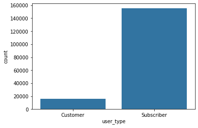

```python
# Plot a simple bar chart for `user_type` column counts
sb.countplot (data= bike, x= 'user_type', color = base_color);
```

Plot a simple Pie chart for `user_type` column proportions

```
(-1.107227055977277,
 1.1072652503469698,
 -1.1056067099403815,
 1.1088855963838653)
```

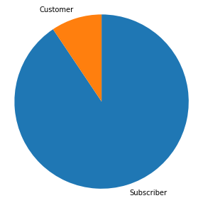

```python
# plotting a pie chart for `user_type` column
sorted_counts = bike['user_type'].value_counts()

plt.pie(sorted_counts, labels = sorted_counts.index, startangle = 90, counterclock = False);

# We have the used option `Square`.
plt.axis('square')
```

> - It is abvious that most of the users are subscribers, and a very litte number of users are just customers.
> - It seems that subscribtion into the bike-sharing system afford better opportunities to use bikes.

Plot a simple bar chart for `member_gender` column counts

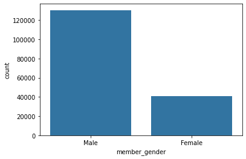

```python
# Plot a simple bar chart for `member_gender` column counts
# Dynamic-ordering the bars
freq_gender = bike['member_gender'].value_counts()

# Get the indexes of the Series
gen_order = freq_gender.index

# Plot the bar chart in the decreasing order of the frequency of the `member_gender`
sb.countplot (data= bike, x= 'member_gender', color = base_color, order=gen_order);
```

Plot a simple Pie chart for `member_gender` column proportions

```
(-1.1051163218076183,
 1.105141769759798,
 -1.1039343710630158,
 1.1063237205044005)
```

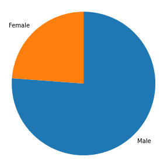

```python
# Plot a simple Pie chart for `member_gender` column proportions
sorted_counts = bike['member_gender'].value_counts()

plt.pie(sorted_counts, labels = sorted_counts.index, startangle = 90, counterclock = False);

# We have the used option `Square`.
plt.axis('square')
```

> - charts indicated that males are the most bike users.

Plot a simple bar chart for `bike_share_for_all_trip` column counts

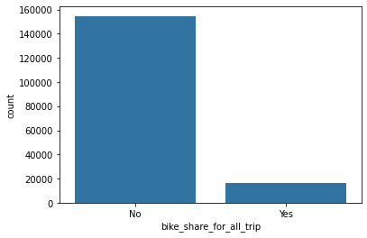

```python
# Plot a simple bar chart for `bike_share_for_all_trip` column counts
sb.countplot (data= bike, x= 'bike_share_for_all_trip', color = base_color);
```

Plot a simple Pie chart for `bike_share_for_all_trip` column proportions

```
(-1.1075631172289493,
 1.1070388856891105,
 -1.1048036060720068,
 1.109798396846053)
```

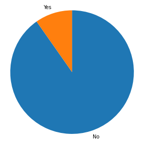

```python
# Plot a simple Pie chart for `bike_share_for_all_trip` column proportions
sorted_counts = bike['bike_share_for_all_trip'].value_counts()

plt.pie(sorted_counts, labels = sorted_counts.index, startangle = 90, counterclock = False);

# We have the used option `Square`.
plt.axis('square')
```

> - It seems that most of the users don't use bike share for all trips.

Plot a simple bar chart for `Start_Date` column

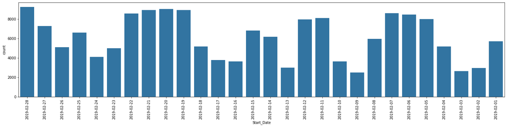

```python
# Plot a simple bar chart for `Start_Date` column
sb.countplot (data= bike, x= 'Start_Date', color = base_color);

# Specify the figure size in inches, for both X, and Y axes
rcParams['figure.figsize'] = 25,5

# Use xticks to rotate the category labels (not axes) counter-clockwise
plt.xticks(rotation = 90);
```

> - when looking at the calender, it is obvios that the peaks of using bike share system where in working days from monday till friday.
> - Weekends are the least days of using bike share system.

Plot a simple bar chart for `end_Date` column

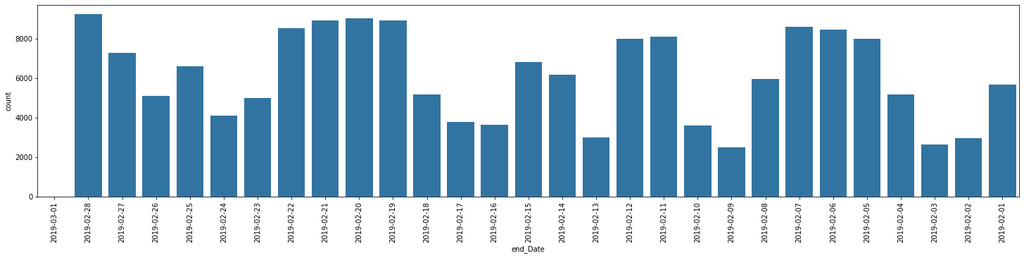

```python
# Plot a simple bar chart for `end_Date` column
sb.countplot (data= bike, x= 'end_Date', color = base_color);

# Specify the figure size in inches, for both X, and Y axes
rcParams['figure.figsize'] = 25,5

# Use xticks to rotate the category labels (not axes) counter-clockwise
plt.xticks(rotation = 90);
```

> - when looking at the calender, it is obvios that the peaks of using bike share system where in working days from monday till friday.
> - Weekends are the least days of using bike share system.

Plot a simple bar chart for `member_birth_year` column counts

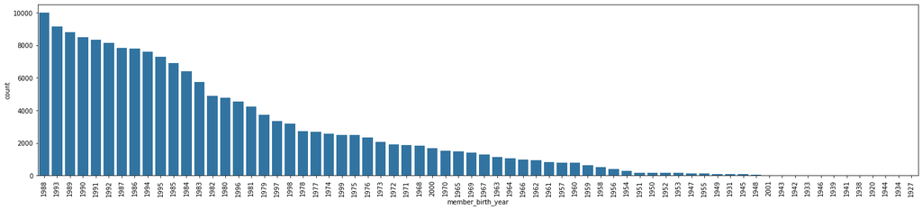

```python
# Dynamic-ordering the bars
freq_birth = bike['member_birth_year'].value_counts()

# Get the indexes of the Series
birth_order = freq_birth.index

# Plot the bar chart in the decreasing order of the frequency of the `member_gender`
sb.countplot (data= bike, x= 'member_birth_year', color = base_color, order=birth_order);

# Specify the figure size in inches, for both X, and Y axes
rcParams['figure.figsize'] = 25,5

# Use xticks to rotate the category labels (not axes) counter-clockwise
plt.xticks(rotation = 90);
```

> - It seems that most of the users are born from 1980 and younger ones.
> - The graph contains large data points, we will use histogram instead of bar chart

Plot a simple bar chart for `start_station_name` column counts

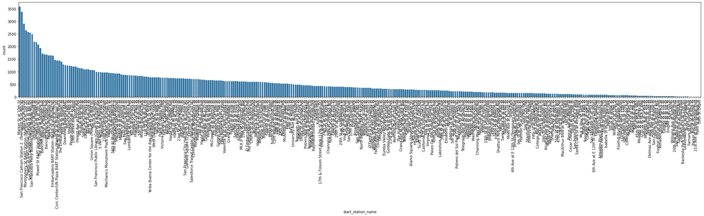

```python
# Dynamic-ordering the bars
freq_start = bike['start_station_name'].value_counts()

# Get the indexes of the Series
start_order = freq_start.index

# Plot the bar chart in the decreasing order of the frequency of the `start_station_name`
sb.countplot (data= bike, x= 'start_station_name', color = base_color, order= start_order);

# Specify the figure size in inches, for both X, and Y axes
rcParams['figure.figsize'] = 25,5

# Use xticks to rotate the category labels (not axes) counter-clockwise
plt.xticks(rotation = 90);
```

```python
bike['start_station_name'].describe()
```

```
count                   171234
unique                     329
top       Market St at 10th St
freq                      3576
Name: start_station_name, dtype: object
```

> - The most famous station and of high trip densities is Market St at 10th St, with 3576 total trips.

Plot a simple bar chart for `end_station_name` column counts

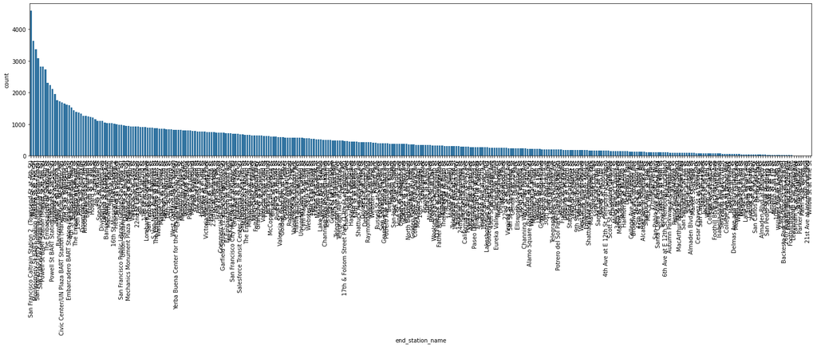

```python
# Dynamic-ordering the bars
freq_end = bike['end_station_name'].value_counts()

# Get the indexes of the Series
end_order = freq_end.index

# Plot the bar chart in the decreasing order of the frequency of the `end_station_name`
sb.countplot (data= bike, x= 'end_station_name', color = base_color, order= end_order);

# Specify the figure size in inches, for both X, and Y axes
rcParams['figure.figsize'] = 25,5

# Use xticks to rotate the category labels (not axes) counter-clockwise
plt.xticks(rotation = 90);
```

```python
bike['end_station_name'].describe()
```

```
count                                                171234
unique                                                  329
top       San Francisco Caltrain Station 2  (Townsend St...
freq                                                   4582
Name: end_station_name, dtype: object
```

> - The most famous end station and of high trip densities is San Francisco Caltrain Station 2 , with 4582 total trips.

### Ploting histograms

Plot a Histogram for `member_birth_year` column counts

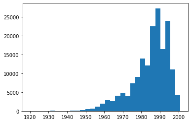

```python
# Plot a Histogram
plt.hist(data = bike, x = 'member_birth_year', bins = 30)
```

> We have outliers in the `member_birth_year` column

```python
bike['member_birth_year'].describe()
```

```
count    171234.000000
mean       1984.874493
std           9.969689
min        1920.000000
25%        1980.000000
50%        1987.000000
75%        1992.000000
max        2001.000000
Name: member_birth_year, dtype: float64
```

Plot a Histogram for `member_birth_year` column, after excluding the outliers

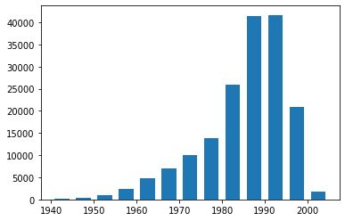

```python
# Create bins with step-size 5
bins = np.arange(1940, bike['member_birth_year'].max()+5, 5)
plt.hist(data = bike, x = 'member_birth_year', bins = bins, rwidth = 0.7);
```

Plot two histograms side-by-side for `member_birth_year` column

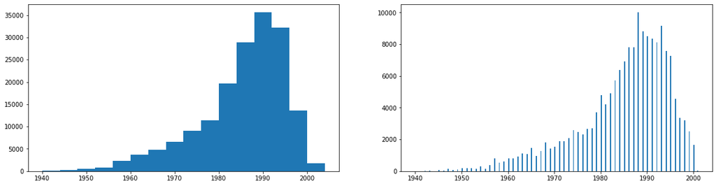

```python
# Resize the chart, and have two plots side-by-side
# Set a larger figure size for subplots
plt.figure(figsize = [20, 5])

# histogram on left, example of too-large bin size
# 1 row, 2 cols, subplot 1
plt.subplot(1, 2, 1)
bins = np.arange(1940, bike['member_birth_year'].max()+4, 4)
plt.hist(data = bike, x = 'member_birth_year', bins = bins);

# histogram on right, example of too-small bin size
plt.subplot(1, 2, 2) # 1 row, 2 cols, subplot 2
bins = np.arange(1940, bike['member_birth_year'].max()+1/4, 1/4)
plt.hist(data = bike, x = 'member_birth_year', bins = bins);
```

Plot the similar histogram with Seaborn's distplot()

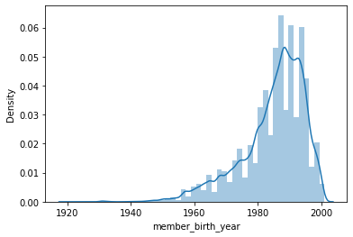

```python
# Plot a histogram with Seaborn's distplot()
sb.distplot(bike['member_birth_year'])
```

> From the histograms we could conclude that young users born from 1980 and further are the most users of the bike share system

Plot a histogram for `duration_sec` column

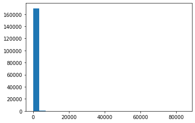

```python
# Plot a histogram
plt.hist(data = bike, x = 'duration_sec', bins = 25);
```

```python
bike['duration_sec'].describe()
```

```
count    171234.000000
mean        697.775559
std        1577.550958
min          61.000000
25%         322.250000
50%         509.000000
75%         787.000000
max       84548.000000
Name: duration_sec, dtype: float64
```

```python
bike['duration_sec'].sort_values()
```

```
96618        61
47819        61
18478        61
41907        61
77248        61
          ...
8114      81549
4878      83195
104948    83407
119513    83519
79867     84548
Name: duration_sec, Length: 171234, dtype: int64
```

> - We have outliers in the duration of rides

Plot a histogram for `duration_sec` column after excluding outliers and setting the maximum limit on X-axis to 4500 sec

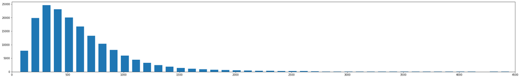

```python
# Create bins with step-size 5
bins = np.arange(61, bike['duration_sec'].max()+5, 100)
plt.hist(data = bike, x = 'duration_sec', bins = bins, rwidth = 0.7);

# Set the upper and lower bounds of the bins that are displayed in the plot
plt.xlim((0,4500));
```

Plot the similar histogram with Seaborn's distplot()

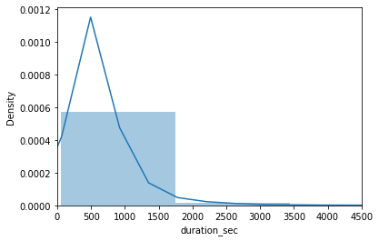

```python
# Plot the similar histogram with Seaborn's distplot()
sb.distplot(bike['duration_sec'])

# Set the upper and lower bounds of the bins that are displayed in the plot
plt.xlim((0,4500));
```

> - from the histograms we could conclude that the duration of most trips is short.

### Findings of Univariate data visualization

- From the previous univariate exploration, it was abserved that males, subscribers, and those born after 1980 are the most categories used the bike sharing system.
- Also, the density of biking was observed in working days of the week. Weekends had the least biking activities.
- In the next step we will look for some relationships between the previous variables.

### Discuss the distribution(s) of your variable(s) of interest. Were there any unusual points? Did you need to perform any transformations?

> - Age data had unusual years of birth (should be deleted).
> - Duration of trips has a very wide range of values (but are valuable information).
> - Most of trips are for short distances and short time.

### Of the features you investigated, were there any unusual distributions? Did you perform any operations on the data to tidy, adjust, or change the form of the data? If so, why did you do this?

> - The column of `member_birth_year` had years over 100 years ago which is unlogical and was cleaned to adjust the age to maximum 100 years as a maximum limit.
> - The column of `member_gender` has a third category called "Other", which was cleaned to adjust the analysis.
> - All "NaN" values was cleaned.

## Bivariate Exploration

> In this section, I will investigate relationships between pairs of variables in the dataset, which were previously investigated in univariate visualizations.

### Plotting scatter plots

> (Plot two quantitative variables)

Scatter plot between `member_birth_year` and `duration_sec` columns by matplotlib

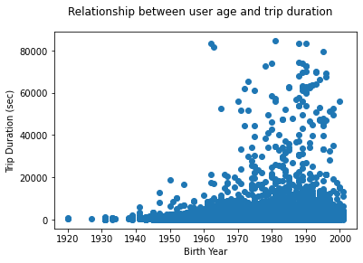

```python
# Scatter plot between 'member_birth_year' and 'duration_sec' columns
plt.scatter(data = bike, x = 'member_birth_year', y = 'duration_sec');

# Titels of both axis and figure
plt.xlabel('Birth Year')
plt.ylabel('Trip Duration (sec)')
plt.suptitle('Relationship between user age and trip duration', fontsize=12)
```

Scatter plot between `member_birth_year` and `duration_sec` columns by Seaborn

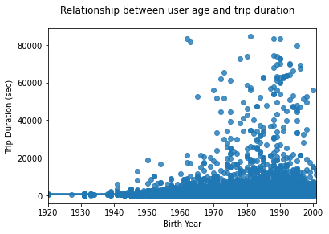

```python
# Scatter plot between 'member_birth_year' and 'duration_sec' columns
sb.regplot(data = bike, x = 'member_birth_year', y = 'duration_sec');

# Titels of both axis and figure
plt.xlabel('Birth Year')
plt.ylabel('Trip Duration (sec)')
plt.suptitle('Relationship between user age and trip duration', fontsize=12)
```

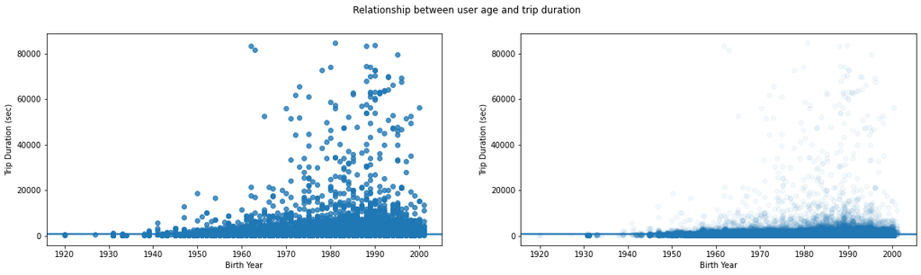

```python
plt.figure(figsize = [20, 5])

# PLOT ON LEFT
plt.subplot(1, 2, 1)
sb.regplot(data = bike, x = 'member_birth_year', y = 'duration_sec', truncate=False);
plt.xlabel('Birth Year')
plt.ylabel('Trip Duration (sec)')
plt.suptitle('Relationship between user age and trip duration', fontsize=12)

# PLOT ON RIGHT
plt.subplot(1, 2, 2)
sb.regplot(data = bike, x = 'member_birth_year', y = 'duration_sec', truncate=False, x_jitter=0.3, scatter_kws={'alpha':1/20});
plt.xlabel('Birth Year')
plt.ylabel('Trip Duration (sec)')
plt.suptitle('Relationship between user age and trip duration', fontsize=12)
```

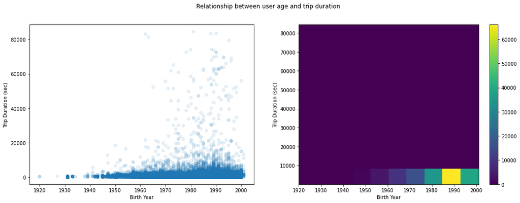

```python
plt.figure(figsize = [18, 6])

# PLOT ON LEFT
plt.subplot(1, 2, 1)
sb.regplot(data = bike, x = 'member_birth_year', y = 'duration_sec', x_jitter=0.04, scatter_kws={'alpha':1/10}, fit_reg=False)
plt.xlabel('Birth Year')
plt.ylabel('Trip Duration (sec)')
plt.suptitle('Relationship between user age and trip duration', fontsize=12)

# PLOT ON RIGHT
plt.subplot(1, 2, 2)
plt.hist2d(data = bike, x = 'member_birth_year', y = 'duration_sec')
plt.colorbar()
plt.xlabel('Birth Year')
plt.ylabel('Trip Duration (sec)')
plt.suptitle('Relationship between user age and trip duration', fontsize=12)
```

### Plotting Violin and Box plots

> (Plot one quantitative and one qualitative variables)

Violin and Box plots between `member_gender` and `duration_sec` columns

```
(-4626.680767062904, 89093.44043455659)
```

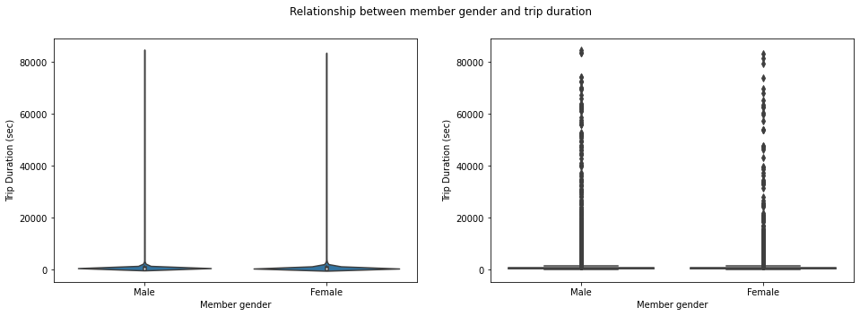

```python
# Violin and Box plots between `member_gender` and `duration_sec` columns
plt.figure(figsize = [16, 5])
base_color = sb.color_palette()[0]

# LEFT plot: violin plot
plt.subplot(1, 2, 1)
# Let's return the axes object
ax1 = sb.violinplot(data=bike, x='member_gender', y='duration_sec', color=base_color, innner='quartile')
plt.xlabel('Member gender')
plt.ylabel('Trip Duration (sec)')
plt.suptitle('Relationship between member gender and trip duration', fontsize=12);

# RIGHT plot: box plot
plt.subplot(1, 2, 2)
sb.boxplot(data=bike, x='member_gender', y='duration_sec', color=base_color)
plt.xlabel('Member gender')
plt.ylabel('Trip Duration (sec)')
plt.suptitle('Relationship between member gender and trip duration', fontsize=12);
plt.ylim(ax1.get_ylim()) # set y-axis limits to be same as left plot
```

Violin and Box plots between `user_type` and `duration_sec` columns

```
(-5169.340147011504, 89061.53944415224)
```

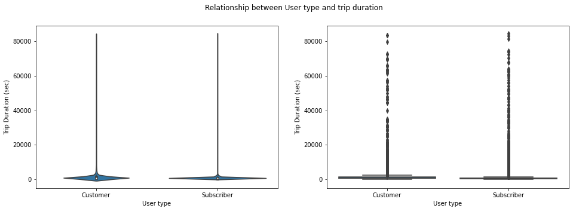

```python
# Violin and Box plots between `user_type` and `duration_sec` columns
plt.figure(figsize = [16, 5])
base_color = sb.color_palette()[0]

# LEFT plot: violin plot
plt.subplot(1, 2, 1)
#Let's return the axes object
ax1 = sb.violinplot(data=bike, x='user_type', y='duration_sec', color=base_color, innner='quartile')
plt.xlabel('User type')
plt.ylabel('Trip Duration (sec)')
plt.suptitle('Relationship between User type and trip duration', fontsize=12);

# RIGHT plot: box plot
plt.subplot(1, 2, 2)
sb.boxplot(data=bike, x='user_type', y='duration_sec', color=base_color)
plt.xlabel('User type')
plt.ylabel('Trip Duration (sec)')
plt.suptitle('Relationship between User type and trip duration', fontsize=12);
plt.ylim(ax1.get_ylim()) # set y-axis limits to be same as left plot
```

Violin and Box plots between `bike_share_for_all_trip` and `duration_sec` columns

```
(-4663.734270449278, 89098.30924932996)
```

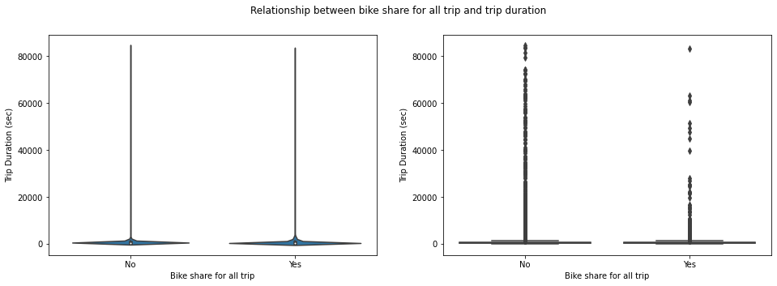

```python
# Violin and Box plots between `bike_share_for_all_trip` and `duration_sec` columns
plt.figure(figsize = [16, 5])
base_color = sb.color_palette()[0]

# LEFT plot: violin plot
plt.subplot(1, 2, 1)
#Let's return the axes object
ax1 = sb.violinplot(data=bike, x='bike_share_for_all_trip', y='duration_sec', color=base_color, innner='quartile')
plt.xlabel('Bike share for all trip')
plt.ylabel('Trip Duration (sec)')
plt.suptitle('Relationship between bike share for all trip and trip duration', fontsize=12);

# RIGHT plot: box plot
plt.subplot(1, 2, 2)
sb.boxplot(data=bike, x='bike_share_for_all_trip', y='duration_sec', color=base_color)
plt.xlabel('Bike share for all trip')
plt.ylabel('Trip Duration (sec)')
plt.suptitle('Relationship between bike share for all trip and trip duration', fontsize=12);
plt.ylim(ax1.get_ylim()) # set y-axis limits to be same as left plot
```

> Violin and Box plots indicated the presence of vast ranges of outliers in trip durations, that made the figures not indicative.